# 17. 작업 1유형 - 6

```python
import pandas as pd
df= pd.read_csv('https://raw.githubusercontent.com/Datamanim/datarepo/main/consum/Tetuan%20City%20power%20consumption.csv')
df
```

|  | DateTime | Temperature | Humidity | Wind Speed | general diffuse flows | diffuse flows | Zone 1 Power Consumption | Zone 2 Power Consumption | Zone 3 Power Consumption |
| --- | --- | --- | --- | --- | --- | --- | --- | --- | --- |
| 0 | 1/1/2017 0:00 | 6.559 | 73.8 | 0.083 | 0.051 | 0.119 | 34055.69620 | 16128.87538 | 20240.96386 |
| 1 | 1/1/2017 0:10 | 6.414 | 74.5 | 0.083 | 0.070 | 0.085 | 29814.68354 | 19375.07599 | 20131.08434 |
| 2 | 1/1/2017 0:20 | 6.313 | 74.5 | 0.080 | 0.062 | 0.100 | 29128.10127 | 19006.68693 | 19668.43373 |
| 3 | 1/1/2017 0:30 | 6.121 | 75.0 | 0.083 | 0.091 | 0.096 | 28228.86076 | 18361.09422 | 18899.27711 |
| 4 | 1/1/2017 0:40 | 5.921 | 75.7 | 0.081 | 0.048 | 0.085 | 27335.69620 | 17872.34043 | 18442.40964 |
| ... | ... | ... | ... | ... | ... | ... | ... | ... | ... |
| 52411 | 12/30/2017 23:10 | 7.010 | 72.4 | 0.080 | 0.040 | 0.096 | 31160.45627 | 26857.31820 | 14780.31212 |
| 52412 | 12/30/2017 23:20 | 6.947 | 72.6 | 0.082 | 0.051 | 0.093 | 30430.41825 | 26124.57809 | 14428.81152 |
| 52413 | 12/30/2017 23:30 | 6.900 | 72.8 | 0.086 | 0.084 | 0.074 | 29590.87452 | 25277.69254 | 13806.48259 |
| 52414 | 12/30/2017 23:40 | 6.758 | 73.0 | 0.080 | 0.066 | 0.089 | 28958.17490 | 24692.23688 | 13512.60504 |
| 52415 | 12/30/2017 23:50 | 6.580 | 74.1 | 0.081 | 0.062 | 0.111 | 28349.80989 | 24055.23167 | 13345.49820 |

52416 rows × 9 columns

## 1. DateTime컬럼을 통해 각 월별로 몇개의 데이터가 있는지 데이터 프레임

```python
df.info()
```

```
<class 'pandas.core.frame.DataFrame'>
RangeIndex: 52416 entries, 0 to 52415
Data columns (total 9 columns):
 #   Column                     Non-Null Count  Dtype
---  ------                     --------------  -----
 0   DateTime                   52416 non-null  object
 1   Temperature                52416 non-null  float64
 2   Humidity                   52416 non-null  float64
 3   Wind Speed                 52416 non-null  float64
 4   general diffuse flows      52416 non-null  float64
 5   diffuse flows              52416 non-null  float64
 6   Zone 1 Power Consumption   52416 non-null  float64
 7   Zone 2  Power Consumption  52416 non-null  float64
 8   Zone 3  Power Consumption  52416 non-null  float64
dtypes: float64(8), object(1)
memory usage: 3.6+ MB
```

```python
df.groupby(pd.to_datetime(df['DateTime']).dt.month).size().to_frame()
```

| DateTime | 0 |
| --- | --- |
| 1 | 4464 |
| 2 | 4032 |
| 3 | 4464 |
| 4 | 4320 |
| 5 | 4464 |
| 6 | 4320 |
| 7 | 4464 |
| 8 | 4464 |
| 9 | 4320 |
| 10 | 4464 |
| 11 | 4320 |
| 12 | 4320 |

```python
df['DateTime']=pd.to_datetime(df['DateTime'])
df
```

|  | DateTime | Temperature | Humidity | Wind Speed | general diffuse flows | diffuse flows | Zone 1 Power Consumption | Zone 2 Power Consumption | Zone 3 Power Consumption |
| --- | --- | --- | --- | --- | --- | --- | --- | --- | --- |
| 0 | 2017-01-01 00:00:00 | 6.559 | 73.8 | 0.083 | 0.051 | 0.119 | 34055.69620 | 16128.87538 | 20240.96386 |
| 1 | 2017-01-01 00:10:00 | 6.414 | 74.5 | 0.083 | 0.070 | 0.085 | 29814.68354 | 19375.07599 | 20131.08434 |
| 2 | 2017-01-01 00:20:00 | 6.313 | 74.5 | 0.080 | 0.062 | 0.100 | 29128.10127 | 19006.68693 | 19668.43373 |
| 3 | 2017-01-01 00:30:00 | 6.121 | 75.0 | 0.083 | 0.091 | 0.096 | 28228.86076 | 18361.09422 | 18899.27711 |
| 4 | 2017-01-01 00:40:00 | 5.921 | 75.7 | 0.081 | 0.048 | 0.085 | 27335.69620 | 17872.34043 | 18442.40964 |
| ... | ... | ... | ... | ... | ... | ... | ... | ... | ... |
| 52411 | 2017-12-30 23:10:00 | 7.010 | 72.4 | 0.080 | 0.040 | 0.096 | 31160.45627 | 26857.31820 | 14780.31212 |
| 52412 | 2017-12-30 23:20:00 | 6.947 | 72.6 | 0.082 | 0.051 | 0.093 | 30430.41825 | 26124.57809 | 14428.81152 |
| 52413 | 2017-12-30 23:30:00 | 6.900 | 72.8 | 0.086 | 0.084 | 0.074 | 29590.87452 | 25277.69254 | 13806.48259 |
| 52414 | 2017-12-30 23:40:00 | 6.758 | 73.0 | 0.080 | 0.066 | 0.089 | 28958.17490 | 24692.23688 | 13512.60504 |
| 52415 | 2017-12-30 23:50:00 | 6.580 | 74.1 | 0.081 | 0.062 | 0.111 | 28349.80989 | 24055.23167 | 13345.49820 |

52416 rows × 9 columns

## 2. 3월달의 각 시간대별 온도의 평균들 중 가장 낮은 시간대의 온도를 출력

```python
df[df['DateTime'].dt.month==3].groupby(df['DateTime'].dt.hour).Temperature.mean().min()
```

```
11.506612903225806
```

## 3. 3월달의 각 시간대별 온도의 평균들 중 가장 높은 시간대의 온도를 출력

```python
df[df['DateTime'].dt.month==3].groupby(df['DateTime'].dt.hour).Temperature.mean().max()
```

```
18.393602150537635
```

## 4. Zone 1 Power Consumption 컬럼의 value값의 크기가 Zone 2 Power Consumption 컬럼의 value값의 크기보다 큰 데이터들의 Humidity의 평균

```python
df[df['Zone 1 Power Consumption']>df['Zone 2  Power Consumption']].Humidity.mean()
```

```
68.23624448055052
```

## 5. 각 zone의 에너지 소비량의 상관관계를 구해서 데이터 프레임으로 표기

```python
df.iloc[:,6:9].corr()
```

|  | Zone 1 Power Consumption | Zone 2 Power Consumption | Zone 3 Power Consumption |
| --- | --- | --- | --- |
| Zone 1 Power Consumption | 1.000000 | 0.834519 | 0.750733 |
| Zone 2 Power Consumption | 0.834519 | 1.000000 | 0.570932 |
| Zone 3 Power Consumption | 0.750733 | 0.570932 | 1.000000 |

## 6. Temperature의 값이 10미만의 경우 A, 10이상 20미만의 경우 B,20이상 30미만의 경우 C, 그 외의 경우 D라고 할때 각 단계의 데이터 숫자

```python
def tj(x):
    if x < 10:
        return 'A'
    elif x < 20:
        return 'B'
    elif x < 30:
        return 'C'
    else:
        return 'D'

df['tj'] = df['Temperature'].apply(tj)
df.groupby('tj').size()
```

```
tj
A     2874
B    26993
C    21105
D     1444
dtype: int64
```

## 7. 6월 데이터중 12시의 Temperature의 표준편차

```python
df[(df['DateTime'].dt.month == 6)&(df['DateTime'].dt.hour == 12)].Temperature.std()
```

```
2.049941782795103
```

## 8. 6월 데이터중 12시의 Temperature의 분산

```python
df[(df['DateTime'].dt.month == 6)&(df['DateTime'].dt.hour == 12)].Temperature.var()
```

```
4.202261312849164
```

## 9. Temperature의 평균이상의 Temperature의 값을 가지는 데이터를 Temperature를 기준으로 정렬 했을때 4번째 행의 Humidity

```python
df[df['Temperature']>=df['Temperature'].mean()].sort_values('Temperature').Humidity.iloc[3]
```

```
79.7
```

## 10.Temperature의 중간값 이상의 Temperature의 값을 가지는 데이터를Temperature를 기준으로 정렬 했을때 4번째 행의 Humidity

```python
df[df['Temperature']>=df['Temperature'].median()].sort_values('Temperature').Humidity.iloc[3]
```

```
87.8
```

## 번외: 분석 및 시각화

```python
df= pd.read_csv('https://raw.githubusercontent.com/Datamanim/datarepo/main/consum/Tetuan%20City%20power%20consumption.csv')
```

```python
df.info()
```

```
<class 'pandas.core.frame.DataFrame'>
RangeIndex: 52416 entries, 0 to 52415
Data columns (total 9 columns):
 #   Column                     Non-Null Count  Dtype
---  ------                     --------------  -----
 0   DateTime                   52416 non-null  object
 1   Temperature                52416 non-null  float64
 2   Humidity                   52416 non-null  float64
 3   Wind Speed                 52416 non-null  float64
 4   general diffuse flows      52416 non-null  float64
 5   diffuse flows              52416 non-null  float64
 6   Zone 1 Power Consumption   52416 non-null  float64
 7   Zone 2  Power Consumption  52416 non-null  float64
 8   Zone 3  Power Consumption  52416 non-null  float64
dtypes: float64(8), object(1)
memory usage: 3.6+ MB
```

```python
df.iloc[:,1:9].corr()
```

|  | Temperature | Humidity | Wind Speed | general diffuse flows | diffuse flows | Zone 1 Power Consumption | Zone 2 Power Consumption | Zone 3 Power Consumption |
| --- | --- | --- | --- | --- | --- | --- | --- | --- |
| Temperature | 1.000000 | -0.460243 | 0.477109 | 0.460294 | 0.196522 | 0.440221 | 0.382428 | 0.489527 |
| Humidity | -0.460243 | 1.000000 | -0.135853 | -0.468138 | -0.256886 | -0.287421 | -0.294961 | -0.233022 |
| Wind Speed | 0.477109 | -0.135853 | 1.000000 | 0.133733 | -0.000972 | 0.167444 | 0.146413 | 0.278641 |
| general diffuse flows | 0.460294 | -0.468138 | 0.133733 | 1.000000 | 0.564718 | 0.187965 | 0.157223 | 0.063376 |
| diffuse flows | 0.196522 | -0.256886 | -0.000972 | 0.564718 | 1.000000 | 0.080274 | 0.044667 | -0.038506 |
| Zone 1 Power Consumption | 0.440221 | -0.287421 | 0.167444 | 0.187965 | 0.080274 | 1.000000 | 0.834519 | 0.750733 |
| Zone 2 Power Consumption | 0.382428 | -0.294961 | 0.146413 | 0.157223 | 0.044667 | 0.834519 | 1.000000 | 0.570932 |
| Zone 3 Power Consumption | 0.489527 | -0.233022 | 0.278641 | 0.063376 | -0.038506 | 0.750733 | 0.570932 | 1.000000 |

### 상관행렬 히트맵

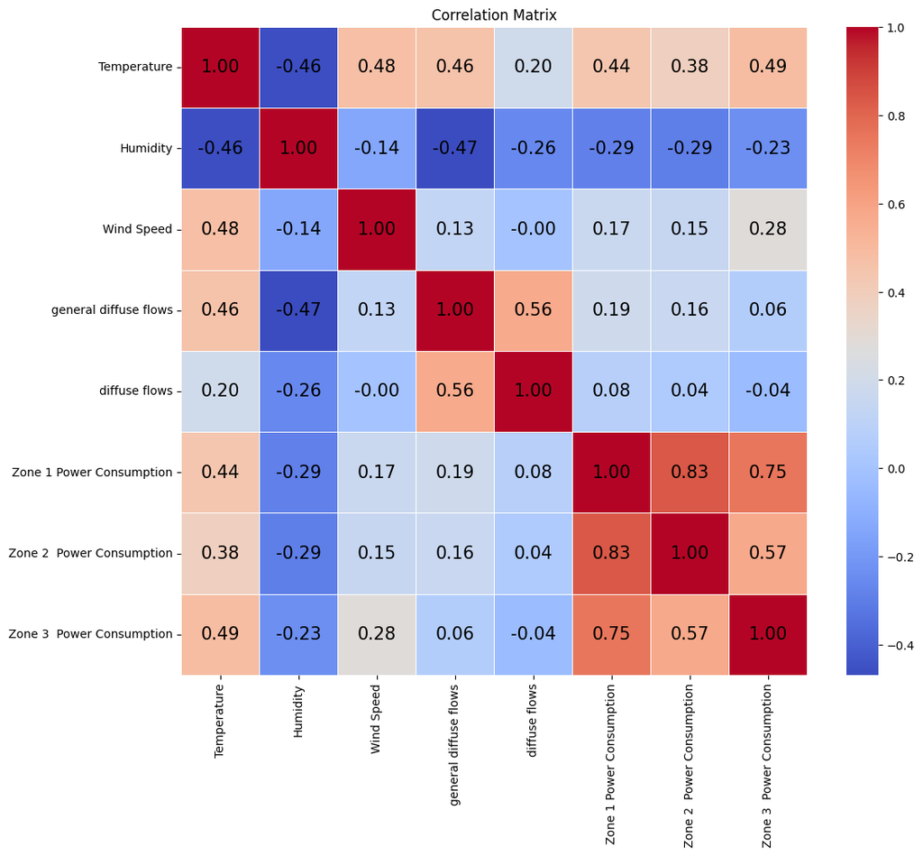

```python
import matplotlib.pyplot as plt
import seaborn as sns

corr_matrix = df.iloc[:,1:9].corr()

plt.figure(figsize=(12, 10))
ax = sns.heatmap(corr_matrix, annot=False, cmap='coolwarm', fmt='.2f', linewidths=0.5)

for i in range(corr_matrix.shape[0]):
    for j in range(corr_matrix.shape[1]):
        plt.text(j + 0.5, i + 0.5, f"{corr_matrix.iloc[i, j]:.2f}",
                 ha='center', va='center', color='black', fontsize=15)

plt.title('Correlation Matrix')
plt.show()
```

### 시간에 따른 변화 일반

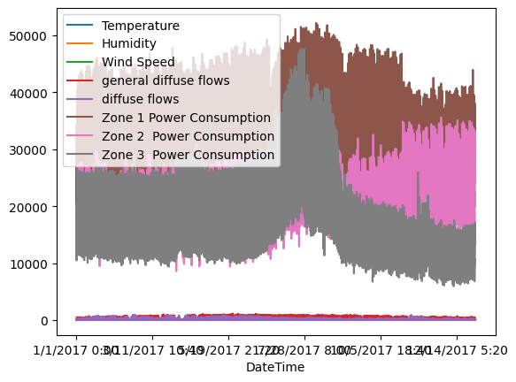

```python
df.set_index('DateTime').plot()
```

### 1구역 전력소모량 산점도 - 온도

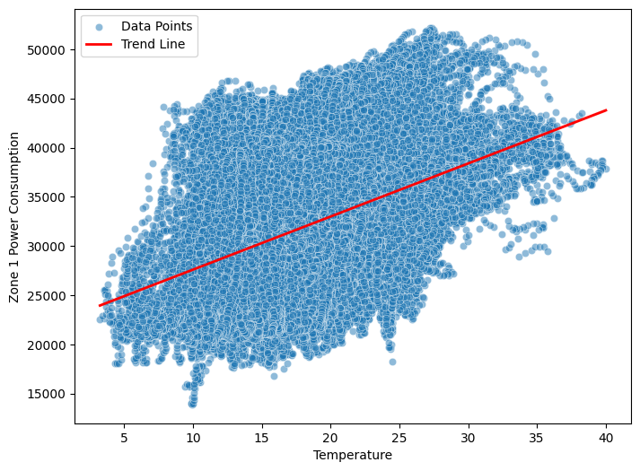

```python
plt.figure(figsize=(8, 6))
sns.scatterplot(x=df['Temperature'], y=df['Zone 1 Power Consumption'], alpha=0.5, label='Data Points')
sns.regplot(x=df['Temperature'], y=df['Zone 1 Power Consumption'], scatter=False, line_kws={"color": "red", "linewidth": 2}, label='Trend Line')
plt.legend()
plt.show()
```

```python
df['Temperature'].corr(df['Zone 1 Power Consumption'])
```

```
0.4402207890291411
```

### 박스플롯: 3구역의 경우, 전력 소모량이 특히 큰 이상치가 많이 관측된다.

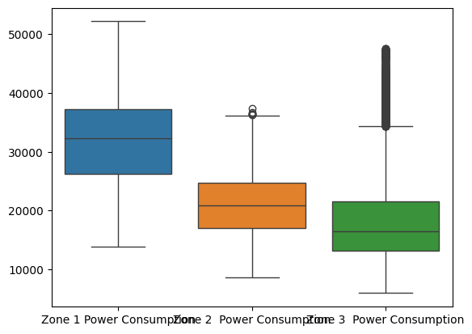

```python
sns.boxplot(data=df[['Zone 1 Power Consumption', 'Zone 2  Power Consumption', 'Zone 3  Power Consumption']])
```

### 막대그래프와 pdf 추정 곡선

```python
from scipy import stats
```

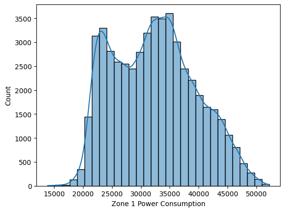

```python
sns.histplot(df['Zone 1 Power Consumption'], bins=30, kde=True)
```

```python
s,p = stats.shapiro(df['Zone 1 Power Consumption'])
p
```

```
3.131256188763489e-63
```

```python
stats.anderson(df['Zone 1 Power Consumption'], dist='norm')
```

```
AndersonResult(statistic=261.43746792721504, critical_values=array([0.576, 0.656, 0.787, 0.918, 1.092]), significance_level=array([15. , 10. ,  5. ,  2.5,  1. ]), fit_result=  params: FitParams(loc=32344.970563585928, scale=7130.562564198575)
 success: True
 message: '`anderson` successfully fit the distribution to the data.')
```

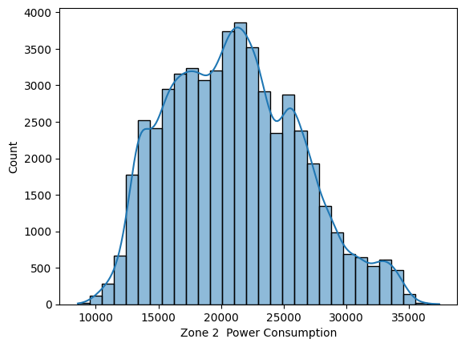

```python
sns.histplot(df['Zone 2  Power Consumption'], bins=30, kde=True)
```

```python
stats.anderson(df['Zone 2  Power Consumption'], dist='norm')
```

```
AndersonResult(statistic=157.5476953635516, critical_values=array([0.576, 0.656, 0.787, 0.918, 1.092]), significance_level=array([15. , 10. ,  5. ,  2.5,  1. ]), fit_result=  params: FitParams(loc=21042.509082321638, scale=5201.465892178961)
 success: True
 message: '`anderson` successfully fit the distribution to the data.')
```

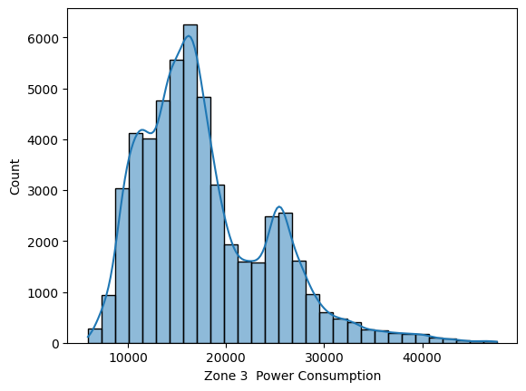

```python
sns.histplot(df['Zone 3  Power Consumption'], bins=30, kde=True)
```

```python
stats.anderson(df['Zone 3  Power Consumption'], dist='norm')
```

```
AndersonResult(statistic=969.2063292877137, critical_values=array([0.576, 0.656, 0.787, 0.918, 1.092]), significance_level=array([15. , 10. ,  5. ,  2.5,  1. ]), fit_result=  params: FitParams(loc=17835.4062183767, scale=6622.165099245576)
 success: True
 message: '`anderson` successfully fit the distribution to the data.')
```

## 결론: 전력 소모량은 정규분포를 따르지 않는 것으로 보이며, 2~3개의 정규분포를 합친 것으로 보인다.